# **Curso de Estadística básica para Data Scientists**

Dae-Jin Lee < lee.daejin@gmail.com >

TEMA 4. Variables Aleatorias y Probabilidad

[Regresar a la página principal](https://idaejin.github.io/bcam-courses/R/datahack/)

# 1 Introducción a la probabilidad

## 1.1 Sucesos

Cuando se realiza un experimento aleatorio diversos resultados son posibles. El conjunto de todos los resultados posibles se llama espacio muestral (E).

Se llama suceso a un subconjunto de resultados

- **Suceso elemental.** Siempre ocurre uno de ellos Son mutuamente excluyentes
- **Suceso compuesto.** Uniones de sucesos elementales

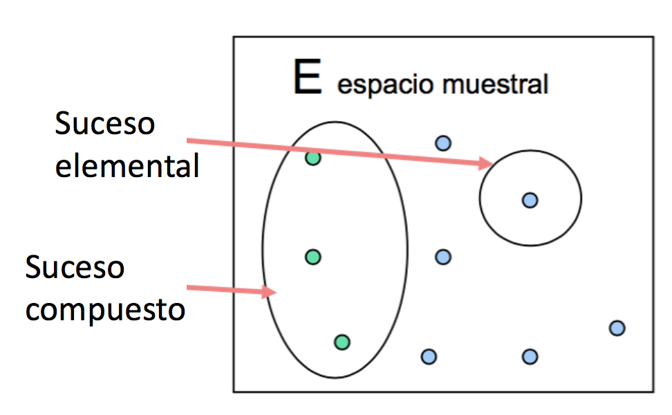

- **Suceso contrario** (complementario) de un suceso A, al formado por los sucesos que no están en A. Se denota como $\bar{A}$

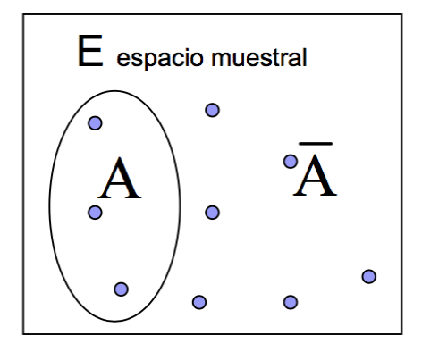

- El **suceso seguro**, $E$, es aquel que siempre ocurre al realizar el experimento
- El **suceso imposible**, $\emptyset$, es aquel que nunca ocurre como resultado del experimento

## 1.2 Operaciones con sucesos

Se llama **suceso intersección** de $A$ y $B$, $A\in B$ o $AB$, al formado por los resultados experimentales que están simultáneamente en $A$ y $B$

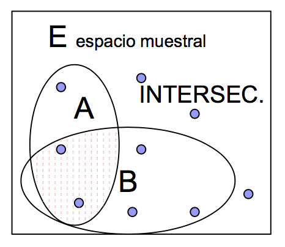

Se dice que dos sucesos $A$ y $B$ son incompatibles si no pueden ocurrir a la vez, $A\in B=\emptyset$

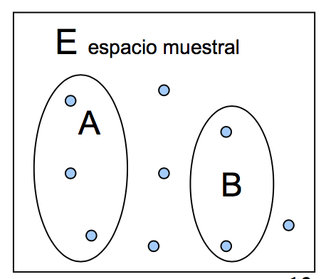

Se llama **suceso unión** de $A$ y $B$, $A\cup B$, al suceso formado por los resultados experimentales que están en $A$ o en $B$ (incluyendo los que están en ambos)

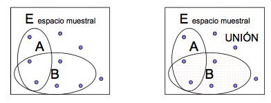

Se llama **suceso diferencia** de $A$ y $B$, $A-B$, al formado por todos los sucesos de $A$ que no están en $B$, es decir, $A\in \bar{B}$. En consecuencia
$$\bar{A} = E - A$$

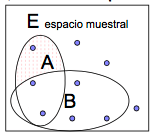

## 1.3 Leyes de Morgan

Hay ciertas propiedades de la unión, intersección y suceso contrario que son conocidas bajo las leyes de Morgan

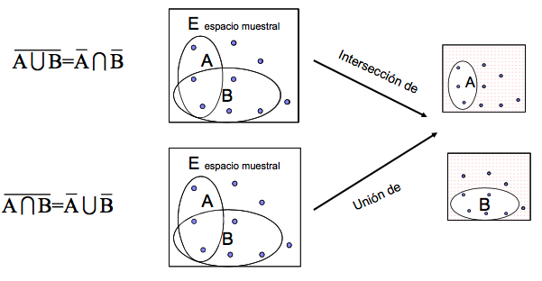

## 1.4 Concepto de Probabilidad

En un experimento aleatorio, cuando el número de veces que se repite aumenta, la frecuencia relativa

$$f_n(A) = \frac{\mbox{Nº Veces que ocurre $A$}}{n}$$

converge hacia una cantidad que llamamos probabilidad

$$Pr(A) = \lim_{n\rightarrow \infty} f_n(A)$$

Esta noción de probabilidad no se usa en la práctica, porque necesitaríamos de $n\rightarrow\infty$. Pero en la práctica podemos simular con el ordenador.

**Ejemplo** La frecuencia relativa del número de caras obtenidos en lanzamientos sucesivos de una moneda

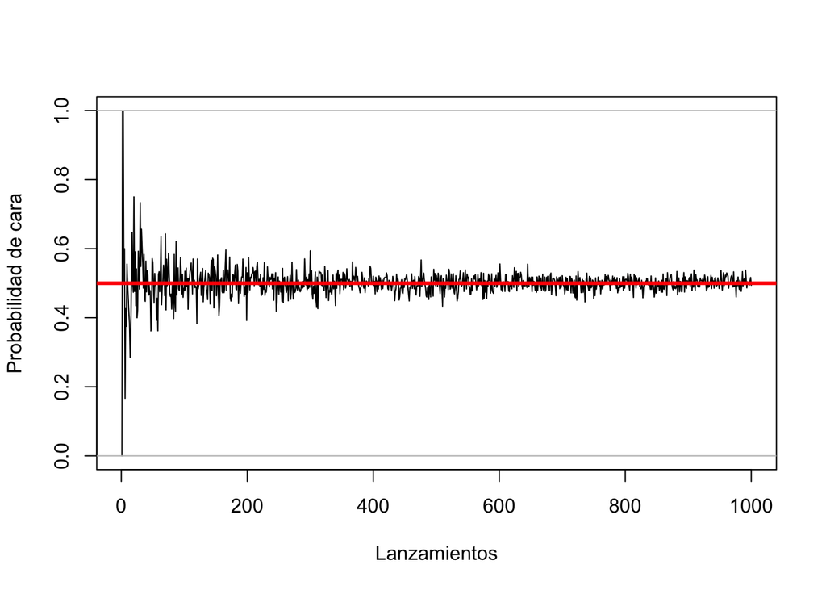

```r
set.seed(1234)
prob <- NULL
for(i in 1:1000){
prob <- c(prob,mean(rbinom(i,1,0.5)))
}
plot(prob,t="l",xlab="Lanzamientos", ylab="Probabilidad de cara",ylim=c(0,1))
abline(h=c(0,0.5,1),col=c("grey","red","grey"),lwd=c(1,3,1))
```

## 1.5 Axiomas de probabilidad

Dado un espacio muestral, $E$, definimos probabilidad como una función, $P$, que asigna a un suceso $A$ un valor numérico $P(A)$, verificando las siguientes reglas (axiomas)

1. $0\leq P(A) \leq 1$
2. $P(E)=1$
3. $P(A\cup B)=P(A)+P(B)$ si $A\in B = \emptyset$

El tercer axioma se generaliza a cualquier número de sucesos de disjuntos:

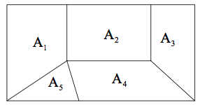

y por tanto

$$Pr\left( \cup_{i=1}^{5}A_i\right) = \sum_{i}^5 Pr(A_i)$$

Estos axiomas no asignan probabilidades a sucesos, pero facilitan el cálculo de probabilidades de unos sucesos a partir de la probabilidad de otros:

1. $Pr(\bar{A}) = 1-Pr(A) \rightarrow E = A \cup \bar{A} \rightarrow Pr(A) + Pr(\bar{A})$
2. $Pr(\emptyset) = 0$ $\rightarrow \emptyset = E$
3. Si $A \subseteq B \rightarrow P(A) \leq P(B)$

## 1.6 Teorema de Bayes

Si $A_1, A_2 ,... , A_n$ son:

- Sucesos incompatibles 2 a 2.
- Cuya unión es el espacio muestral ($A_1 \cup A_2 \cup... \cup A_n = E$).
- Y $B$ es otro suceso.

El teorema de Bayes nos dice que:

$$P(A_i|B) = \frac{P(A_i) \cdot P(B|A_i)}{P(B)}$$

donde
$$P(B) = P(A_1) \cdot P(B|A_1) + P(A_2) \cdot P(B|A_2) + ... +P(A_n) \cdot P(B|A_n)$$

Las probabilidades $p(A_i)$ se denominan probabilidades a priori.

Las probabilidades $p(A_i/B)$ se denominan probabilidades a posteriori.

Las probabilidades $p(B/A_i)$ se denominan verosimilitudes.

**Ejemplo 1** El 20% de los empleados de una empresa son ingenieros y otro 20% son economistas. El 75% de los ingenieros ocupan un puesto directivo y el 50% de los economistas también, mientras que los no ingenieros y los no economistas solamente el 20% ocupa un puesto directivo. ¿Cuál es la probabilidad de que un empleado directivo elegido al azar sea ingeniero?

*Solucion*

¿$P(Ingeniero|Directivo)$?

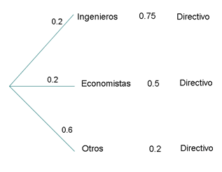

$$\begin{eqnarray*}
P(Ingeniero|Directivo) & = & \frac{P(Ingeniero) \times P(Directivo|Ingeniero)}{P(Directivo)} = \\
& = & \frac{0.2\times 0.75}{0.2 \times 0.75 + 0.2 \times 0.5 + 0.6 \times 0.2} = 0.405
\end{eqnarray*}$$

**Ejemplo 2**

La probabilidad de que haya un accidente en una fábrica que dispone de alarma es 0.1. La probabilidad de que suene esta sí se ha producido algún incidente es de 0.97 y la probabilidad de que suene si no ha sucedido ningún incidente es 0.02.

En el supuesto de que haya funcionado la alarma, ¿cuál es la probabilidad de que no haya habido ningún incidente?

*Solucion*

Sean los sucesos:

$I = \mbox{`Producirse incidente'}$.

$A = \mbox{`Sonar la alarma'}$.

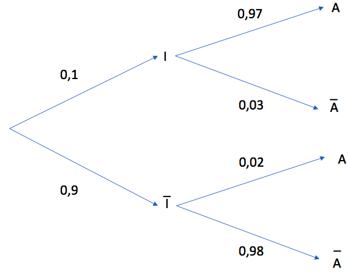